# Risk Factor Analysis

## Outcome Variable

**Outcome Variable:** whz

## Predictor Variables

**Intervention Variable:** predfeed6

**Adjustment Set:**

- arm
- sex
- month
- brthmon
- W_mage
- meducyrs
- feducyrs
- hhwealth_quart
- hfoodsec
- W_mhtcm
- vagbrth
- W_gagebrth
- W_birthwt
- W_birthlen
- W_nrooms
- W_nchldlt5
- W_parity
- impfloor
- impsan
- safeh20
- delta_W_mage
- delta_meducyrs
- delta_feducyrs
- delta_hhwealth_quart
- delta_hfoodsec
- delta_W_mhtcm
- delta_vagbrth
- delta_W_gagebrth
- delta_W_birthwt
- delta_W_birthlen
- delta_W_nrooms
- delta_W_nchldlt5
- delta_W_parity
- delta_impfloor
- delta_impsan
- delta_safeh20

## Stratifying Variables

The analysis was stratified on these variable(s):

- agecat
- studyid
- country

## Data Summary

| agecat | studyid | country | predfeed6 | n_cell | n |
| --- | --- | --- | --- | --- | --- |
| Birth | ki0047075b-MAL-ED | BANGLADESH | 1 | 114 | 219 |
| Birth | ki0047075b-MAL-ED | BANGLADESH | 0 | 105 | 219 |
| Birth | ki0047075b-MAL-ED | BRAZIL | 1 | 26 | 168 |
| Birth | ki0047075b-MAL-ED | BRAZIL | 0 | 142 | 168 |
| Birth | ki0047075b-MAL-ED | INDIA | 1 | 15 | 187 |
| Birth | ki0047075b-MAL-ED | INDIA | 0 | 172 | 187 |
| Birth | ki0047075b-MAL-ED | NEPAL | 1 | 22 | 165 |
| Birth | ki0047075b-MAL-ED | NEPAL | 0 | 143 | 165 |
| Birth | ki0047075b-MAL-ED | PERU | 1 | 104 | 249 |
| Birth | ki0047075b-MAL-ED | PERU | 0 | 145 | 249 |
| Birth | ki0047075b-MAL-ED | SOUTH AFRICA | 1 | 3 | 209 |
| Birth | ki0047075b-MAL-ED | SOUTH AFRICA | 0 | 206 | 209 |
| Birth | ki0047075b-MAL-ED | TANZANIA, UNITED REPUBLIC OF | 1 | 1 | 115 |
| Birth | ki0047075b-MAL-ED | TANZANIA, UNITED REPUBLIC OF | 0 | 114 | 115 |
| Birth | ki1000109-EE | PAKISTAN | 1 | 0 | 1 |
| Birth | ki1000109-EE | PAKISTAN | 0 | 1 | 1 |
| Birth | kiGH5241-JiVitA-3 | BANGLADESH | 1 | 12395 | 15420 |
| Birth | kiGH5241-JiVitA-3 | BANGLADESH | 0 | 3025 | 15420 |
| Birth | kiGH5241-JiVitA-4 | BANGLADESH | 1 | 521 | 633 |
| Birth | kiGH5241-JiVitA-4 | BANGLADESH | 0 | 112 | 633 |
| 6 months | ki0047075b-MAL-ED | BANGLADESH | 1 | 123 | 235 |
| 6 months | ki0047075b-MAL-ED | BANGLADESH | 0 | 112 | 235 |
| 6 months | ki0047075b-MAL-ED | BRAZIL | 1 | 35 | 209 |
| 6 months | ki0047075b-MAL-ED | BRAZIL | 0 | 174 | 209 |
| 6 months | ki0047075b-MAL-ED | INDIA | 1 | 18 | 232 |
| 6 months | ki0047075b-MAL-ED | INDIA | 0 | 214 | 232 |
| 6 months | ki0047075b-MAL-ED | NEPAL | 1 | 29 | 235 |
| 6 months | ki0047075b-MAL-ED | NEPAL | 0 | 206 | 235 |
| 6 months | ki0047075b-MAL-ED | PERU | 1 | 113 | 269 |
| 6 months | ki0047075b-MAL-ED | PERU | 0 | 156 | 269 |
| 6 months | ki0047075b-MAL-ED | SOUTH AFRICA | 1 | 3 | 242 |
| 6 months | ki0047075b-MAL-ED | SOUTH AFRICA | 0 | 239 | 242 |
| 6 months | ki0047075b-MAL-ED | TANZANIA, UNITED REPUBLIC OF | 1 | 2 | 244 |
| 6 months | ki0047075b-MAL-ED | TANZANIA, UNITED REPUBLIC OF | 0 | 242 | 244 |
| 6 months | ki1000109-EE | PAKISTAN | 1 | 220 | 376 |
| 6 months | ki1000109-EE | PAKISTAN | 0 | 156 | 376 |
| 6 months | ki1000304b-SAS-FoodSuppl | INDIA | 1 | 0 | 168 |
| 6 months | ki1000304b-SAS-FoodSuppl | INDIA | 0 | 168 | 168 |
| 6 months | ki1113344-GMS-Nepal | NEPAL | 1 | 404 | 546 |
| 6 months | ki1113344-GMS-Nepal | NEPAL | 0 | 142 | 546 |
| 6 months | ki1148112-LCNI-5 | MALAWI | 1 | 47 | 272 |
| 6 months | ki1148112-LCNI-5 | MALAWI | 0 | 225 | 272 |
| 6 months | kiGH5241-JiVitA-3 | BANGLADESH | 1 | 13186 | 16655 |
| 6 months | kiGH5241-JiVitA-3 | BANGLADESH | 0 | 3469 | 16655 |
| 6 months | kiGH5241-JiVitA-4 | BANGLADESH | 1 | 3331 | 4260 |
| 6 months | kiGH5241-JiVitA-4 | BANGLADESH | 0 | 929 | 4260 |
| 24 months | ki0047075b-MAL-ED | BANGLADESH | 1 | 112 | 209 |
| 24 months | ki0047075b-MAL-ED | BANGLADESH | 0 | 97 | 209 |
| 24 months | ki0047075b-MAL-ED | BRAZIL | 1 | 29 | 169 |
| 24 months | ki0047075b-MAL-ED | BRAZIL | 0 | 140 | 169 |
| 24 months | ki0047075b-MAL-ED | INDIA | 1 | 17 | 224 |
| 24 months | ki0047075b-MAL-ED | INDIA | 0 | 207 | 224 |
| 24 months | ki0047075b-MAL-ED | NEPAL | 1 | 28 | 227 |
| 24 months | ki0047075b-MAL-ED | NEPAL | 0 | 199 | 227 |
| 24 months | ki0047075b-MAL-ED | PERU | 1 | 84 | 198 |
| 24 months | ki0047075b-MAL-ED | PERU | 0 | 114 | 198 |
| 24 months | ki0047075b-MAL-ED | SOUTH AFRICA | 1 | 3 | 227 |
| 24 months | ki0047075b-MAL-ED | SOUTH AFRICA | 0 | 224 | 227 |
| 24 months | ki0047075b-MAL-ED | TANZANIA, UNITED REPUBLIC OF | 1 | 2 | 212 |
| 24 months | ki0047075b-MAL-ED | TANZANIA, UNITED REPUBLIC OF | 0 | 210 | 212 |
| 24 months | ki1113344-GMS-Nepal | NEPAL | 1 | 359 | 479 |
| 24 months | ki1113344-GMS-Nepal | NEPAL | 0 | 120 | 479 |
| 24 months | ki1148112-LCNI-5 | MALAWI | 1 | 34 | 184 |
| 24 months | ki1148112-LCNI-5 | MALAWI | 0 | 150 | 184 |
| 24 months | kiGH5241-JiVitA-3 | BANGLADESH | 1 | 6653 | 8513 |
| 24 months | kiGH5241-JiVitA-3 | BANGLADESH | 0 | 1860 | 8513 |
| 24 months | kiGH5241-JiVitA-4 | BANGLADESH | 1 | 3275 | 4159 |
| 24 months | kiGH5241-JiVitA-4 | BANGLADESH | 0 | 884 | 4159 |

The following strata were considered:

- agecat: 24 months, studyid: ki0047075b-MAL-ED, country: BANGLADESH
- agecat: 24 months, studyid: ki0047075b-MAL-ED, country: BRAZIL
- agecat: 24 months, studyid: ki0047075b-MAL-ED, country: INDIA
- agecat: 24 months, studyid: ki0047075b-MAL-ED, country: NEPAL
- agecat: 24 months, studyid: ki0047075b-MAL-ED, country: PERU
- agecat: 24 months, studyid: ki0047075b-MAL-ED, country: SOUTH AFRICA
- agecat: 24 months, studyid: ki0047075b-MAL-ED, country: TANZANIA, UNITED REPUBLIC OF
- agecat: 24 months, studyid: ki1113344-GMS-Nepal, country: NEPAL
- agecat: 24 months, studyid: ki1148112-LCNI-5, country: MALAWI
- agecat: 24 months, studyid: kiGH5241-JiVitA-3, country: BANGLADESH
- agecat: 24 months, studyid: kiGH5241-JiVitA-4, country: BANGLADESH
- agecat: 6 months, studyid: ki0047075b-MAL-ED, country: BANGLADESH
- agecat: 6 months, studyid: ki0047075b-MAL-ED, country: BRAZIL
- agecat: 6 months, studyid: ki0047075b-MAL-ED, country: INDIA
- agecat: 6 months, studyid: ki0047075b-MAL-ED, country: NEPAL
- agecat: 6 months, studyid: ki0047075b-MAL-ED, country: PERU
- agecat: 6 months, studyid: ki0047075b-MAL-ED, country: SOUTH AFRICA
- agecat: 6 months, studyid: ki0047075b-MAL-ED, country: TANZANIA, UNITED REPUBLIC OF
- agecat: 6 months, studyid: ki1000109-EE, country: PAKISTAN
- agecat: 6 months, studyid: ki1000304b-SAS-FoodSuppl, country: INDIA
- agecat: 6 months, studyid: ki1113344-GMS-Nepal, country: NEPAL
- agecat: 6 months, studyid: ki1148112-LCNI-5, country: MALAWI
- agecat: 6 months, studyid: kiGH5241-JiVitA-3, country: BANGLADESH
- agecat: 6 months, studyid: kiGH5241-JiVitA-4, country: BANGLADESH
- agecat: Birth, studyid: ki0047075b-MAL-ED, country: BANGLADESH
- agecat: Birth, studyid: ki0047075b-MAL-ED, country: BRAZIL
- agecat: Birth, studyid: ki0047075b-MAL-ED, country: INDIA
- agecat: Birth, studyid: ki0047075b-MAL-ED, country: NEPAL
- agecat: Birth, studyid: ki0047075b-MAL-ED, country: PERU
- agecat: Birth, studyid: ki0047075b-MAL-ED, country: SOUTH AFRICA
- agecat: Birth, studyid: ki0047075b-MAL-ED, country: TANZANIA, UNITED REPUBLIC OF
- agecat: Birth, studyid: ki1000109-EE, country: PAKISTAN
- agecat: Birth, studyid: kiGH5241-JiVitA-3, country: BANGLADESH
- agecat: Birth, studyid: kiGH5241-JiVitA-4, country: BANGLADESH

### Dropped Strata

Some strata were dropped due to rare outcomes:

- agecat: Birth, studyid: ki0047075b-MAL-ED, country: SOUTH AFRICA
- agecat: Birth, studyid: ki0047075b-MAL-ED, country: TANZANIA, UNITED REPUBLIC OF
- agecat: Birth, studyid: ki1000109-EE, country: PAKISTAN
- agecat: 6 months, studyid: ki0047075b-MAL-ED, country: SOUTH AFRICA
- agecat: 6 months, studyid: ki0047075b-MAL-ED, country: TANZANIA, UNITED REPUBLIC OF
- agecat: 6 months, studyid: ki1000304b-SAS-FoodSuppl, country: INDIA
- agecat: 24 months, studyid: ki0047075b-MAL-ED, country: SOUTH AFRICA
- agecat: 24 months, studyid: ki0047075b-MAL-ED, country: TANZANIA, UNITED REPUBLIC OF

## Methods Detail

We’re interested in the causal parameters $E[Y_a]$ for all values of $a \in \mathcal{A}$. These parameters represent the mean outcome if, possibly contrary to fact, we intervened to set all units to have $A=a$. Under the randomization and positivity assumptions, these are identified by the statistical parameters $\psi_a=E_W[E_{Y|A,W}(Y|A=a,W)]$. In addition, we’re interested in the mean of $Y$, $E[Y]$ under no intervention (the observed mean). We will estimate these parameters by using SuperLearner to fit the relevant likelihood factors – $E_{Y|A,W}(Y|A=a,W)$ and $p(A=a|W)$, and then updating our likelihood fit using a joint TMLE.

For unadjusted analyses ($W=\{\}$), initial likelihoods were estimated using Lrnr_glm to estimate the simple $E(Y|A)$ and Lrnr_mean to estimate $p(A)$. For adjusted analyses, a small library containing Lrnr_glmnet, Lrnr_xgboost, and Lrnr_mean was used.

Having estimated these parameters, we will then use the delta method to estimate relative risks and attributable risks relative to a prespecified baseline level of $A$.

# Results Detail

## Results Plots

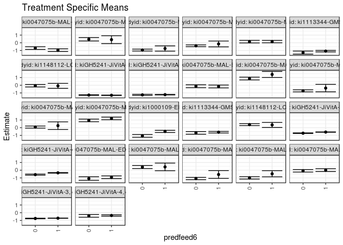

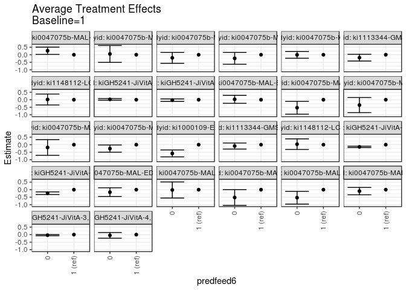

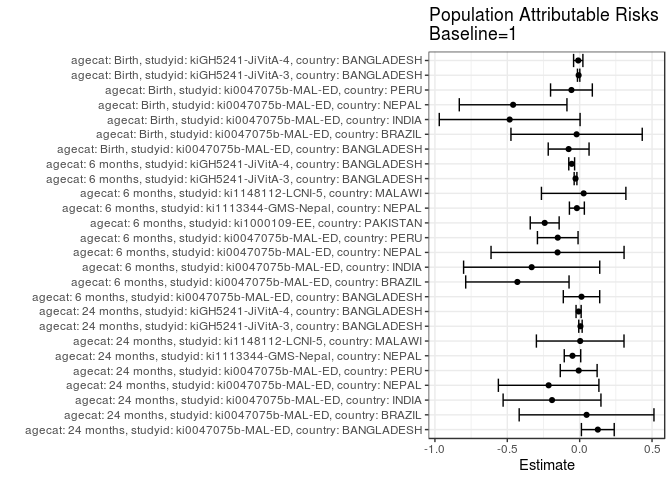

## Results Table

### Parameter: TSM

| agecat | studyid | country | intervention_level | baseline_level | estimate | ci_lower | ci_upper |
| --- | --- | --- | --- | --- | --- | --- | --- |
| Birth | ki0047075b-MAL-ED | BANGLADESH | 1 | NA | -0.9163202 | -1.0930281 | -0.7396124 |
| Birth | ki0047075b-MAL-ED | BANGLADESH | 0 | NA | -1.0826797 | -1.3112221 | -0.8541372 |
| Birth | ki0047075b-MAL-ED | BRAZIL | 1 | NA | 0.4285655 | -0.0695733 | 0.9267043 |
| Birth | ki0047075b-MAL-ED | BRAZIL | 0 | NA | 0.4076855 | 0.2096195 | 0.6057515 |
| Birth | ki0047075b-MAL-ED | INDIA | 1 | NA | -0.5599681 | -1.0630973 | -0.0568390 |
| Birth | ki0047075b-MAL-ED | INDIA | 0 | NA | -1.0803966 | -1.2293480 | -0.9314452 |
| Birth | ki0047075b-MAL-ED | NEPAL | 1 | NA | -0.4627940 | -0.8601074 | -0.0654806 |
| Birth | ki0047075b-MAL-ED | NEPAL | 0 | NA | -0.9970903 | -1.1457102 | -0.8484705 |
| Birth | ki0047075b-MAL-ED | PERU | 1 | NA | 0.0137618 | -0.1684736 | 0.1959971 |
| Birth | ki0047075b-MAL-ED | PERU | 0 | NA | -0.0823430 | -0.2412387 | 0.0765527 |
| Birth | kiGH5241-JiVitA-3 | BANGLADESH | 1 | NA | -0.7162805 | -0.7376000 | -0.6949611 |
| Birth | kiGH5241-JiVitA-3 | BANGLADESH | 0 | NA | -0.7525229 | -0.7921357 | -0.7129102 |
| Birth | kiGH5241-JiVitA-4 | BANGLADESH | 1 | NA | -0.3640226 | -0.4556883 | -0.2723569 |
| Birth | kiGH5241-JiVitA-4 | BANGLADESH | 0 | NA | -0.4131777 | -0.5880108 | -0.2383445 |
| 6 months | ki0047075b-MAL-ED | BANGLADESH | 1 | NA | -0.1591628 | -0.3468218 | 0.0284963 |
| 6 months | ki0047075b-MAL-ED | BANGLADESH | 0 | NA | -0.1304288 | -0.3176355 | 0.0567779 |
| 6 months | ki0047075b-MAL-ED | BRAZIL | 1 | NA | 1.4021352 | 1.0142936 | 1.7899768 |
| 6 months | ki0047075b-MAL-ED | BRAZIL | 0 | NA | 0.8699496 | 0.6918287 | 1.0480705 |
| 6 months | ki0047075b-MAL-ED | INDIA | 1 | NA | -0.3712151 | -0.8536486 | 0.1112183 |
| 6 months | ki0047075b-MAL-ED | INDIA | 0 | NA | -0.7271252 | -0.8591454 | -0.5951049 |
| 6 months | ki0047075b-MAL-ED | NEPAL | 1 | NA | 0.2695368 | -0.2260672 | 0.7651408 |
| 6 months | ki0047075b-MAL-ED | NEPAL | 0 | NA | 0.0839352 | -0.0530142 | 0.2208846 |
| 6 months | ki0047075b-MAL-ED | PERU | 1 | NA | 1.2069285 | 1.0376867 | 1.3761704 |
| 6 months | ki0047075b-MAL-ED | PERU | 0 | NA | 0.9481703 | 0.7785934 | 1.1177473 |
| 6 months | ki1000109-EE | PAKISTAN | 1 | NA | -0.4796286 | -0.6197626 | -0.3394946 |
| 6 months | ki1000109-EE | PAKISTAN | 0 | NA | -1.0588621 | -1.2387186 | -0.8790055 |
| 6 months | ki1113344-GMS-Nepal | NEPAL | 1 | NA | -0.5822325 | -0.6855182 | -0.4789468 |
| 6 months | ki1113344-GMS-Nepal | NEPAL | 0 | NA | -0.6700840 | -0.8421509 | -0.4980171 |
| 6 months | ki1148112-LCNI-5 | MALAWI | 1 | NA | 0.3651840 | 0.0364490 | 0.6939189 |
| 6 months | ki1148112-LCNI-5 | MALAWI | 0 | NA | 0.3999633 | 0.2732607 | 0.5266658 |
| 6 months | kiGH5241-JiVitA-3 | BANGLADESH | 1 | NA | -0.5646256 | -0.5859919 | -0.5432593 |
| 6 months | kiGH5241-JiVitA-3 | BANGLADESH | 0 | NA | -0.7101819 | -0.7524216 | -0.6679421 |
| 6 months | kiGH5241-JiVitA-4 | BANGLADESH | 1 | NA | -0.3420399 | -0.3886624 | -0.2954175 |
| 6 months | kiGH5241-JiVitA-4 | BANGLADESH | 0 | NA | -0.5768238 | -0.6528205 | -0.5008271 |
| 24 months | ki0047075b-MAL-ED | BANGLADESH | 1 | NA | -0.9569939 | -1.1290953 | -0.7848925 |
| 24 months | ki0047075b-MAL-ED | BANGLADESH | 0 | NA | -0.6913674 | -0.8647839 | -0.5179508 |
| 24 months | ki0047075b-MAL-ED | BRAZIL | 1 | NA | 0.3989442 | -0.1136716 | 0.9115600 |
| 24 months | ki0047075b-MAL-ED | BRAZIL | 0 | NA | 0.4530487 | 0.2275611 | 0.6785363 |
| 24 months | ki0047075b-MAL-ED | INDIA | 1 | NA | -0.7481559 | -1.0914489 | -0.4048629 |
| 24 months | ki0047075b-MAL-ED | INDIA | 0 | NA | -0.9534089 | -1.0753147 | -0.8315031 |
| 24 months | ki0047075b-MAL-ED | NEPAL | 1 | NA | -0.1559129 | -0.5323981 | 0.2205724 |
| 24 months | ki0047075b-MAL-ED | NEPAL | 0 | NA | -0.3924104 | -0.5103723 | -0.2744485 |
| 24 months | ki0047075b-MAL-ED | PERU | 1 | NA | 0.1497049 | -0.0038599 | 0.3032696 |
| 24 months | ki0047075b-MAL-ED | PERU | 0 | NA | 0.1418205 | -0.0254163 | 0.3090574 |
| 24 months | ki1113344-GMS-Nepal | NEPAL | 1 | NA | -1.0873407 | -1.1868375 | -0.9878438 |
| 24 months | ki1113344-GMS-Nepal | NEPAL | 0 | NA | -1.2793304 | -1.4794304 | -1.0792303 |
| 24 months | ki1148112-LCNI-5 | MALAWI | 1 | NA | -0.0807814 | -0.4022349 | 0.2406720 |
| 24 months | ki1148112-LCNI-5 | MALAWI | 0 | NA | -0.0642043 | -0.2253979 | 0.0969892 |
| 24 months | kiGH5241-JiVitA-3 | BANGLADESH | 1 | NA | -1.3045507 | -1.3309846 | -1.2781167 |
| 24 months | kiGH5241-JiVitA-3 | BANGLADESH | 0 | NA | -1.2804226 | -1.3279966 | -1.2328485 |
| 24 months | kiGH5241-JiVitA-4 | BANGLADESH | 1 | NA | -1.2263753 | -1.2634295 | -1.1893211 |
| 24 months | kiGH5241-JiVitA-4 | BANGLADESH | 0 | NA | -1.2515258 | -1.3276963 | -1.1753553 |

### Parameter: E(Y)

| agecat | studyid | country | intervention_level | baseline_level | estimate | ci_lower | ci_upper |
| --- | --- | --- | --- | --- | --- | --- | --- |
| Birth | ki0047075b-MAL-ED | BANGLADESH | NA | NA | -0.9925114 | -1.1346572 | -0.8503656 |
| Birth | ki0047075b-MAL-ED | BRAZIL | NA | NA | 0.4073214 | 0.2229599 | 0.5916830 |
| Birth | ki0047075b-MAL-ED | INDIA | NA | NA | -1.0435829 | -1.1865715 | -0.9005943 |
| Birth | ki0047075b-MAL-ED | NEPAL | NA | NA | -0.9226061 | -1.0630064 | -0.7822058 |
| Birth | ki0047075b-MAL-ED | PERU | NA | NA | -0.0430924 | -0.1600210 | 0.0738362 |
| Birth | kiGH5241-JiVitA-3 | BANGLADESH | NA | NA | -0.7234060 | -0.7433920 | -0.7034200 |
| Birth | kiGH5241-JiVitA-4 | BANGLADESH | NA | NA | -0.3738863 | -0.4580087 | -0.2897638 |
| 6 months | ki0047075b-MAL-ED | BANGLADESH | NA | NA | -0.1464929 | -0.2779745 | -0.0150113 |
| 6 months | ki0047075b-MAL-ED | BRAZIL | NA | NA | 0.9717225 | 0.8073791 | 1.1360658 |
| 6 months | ki0047075b-MAL-ED | INDIA | NA | NA | -0.7028736 | -0.8283047 | -0.5774424 |
| 6 months | ki0047075b-MAL-ED | NEPAL | NA | NA | 0.1167518 | -0.0146454 | 0.2481490 |
| 6 months | ki0047075b-MAL-ED | PERU | NA | NA | 1.0554461 | 0.9322755 | 1.1786167 |
| 6 months | ki1000109-EE | PAKISTAN | NA | NA | -0.7212766 | -0.8346857 | -0.6078675 |
| 6 months | ki1113344-GMS-Nepal | NEPAL | NA | NA | -0.6015049 | -0.6892785 | -0.5137313 |
| 6 months | ki1148112-LCNI-5 | MALAWI | NA | NA | 0.3927574 | 0.2737700 | 0.5117448 |
| 6 months | kiGH5241-JiVitA-3 | BANGLADESH | NA | NA | -0.5931801 | -0.6126929 | -0.5736674 |
| 6 months | kiGH5241-JiVitA-4 | BANGLADESH | NA | NA | -0.3971948 | -0.4378192 | -0.3565704 |
| 24 months | ki0047075b-MAL-ED | BANGLADESH | NA | NA | -0.8315789 | -0.9546058 | -0.7085521 |
| 24 months | ki0047075b-MAL-ED | BRAZIL | NA | NA | 0.4466272 | 0.2416144 | 0.6516401 |
| 24 months | ki0047075b-MAL-ED | INDIA | NA | NA | -0.9390848 | -1.0545919 | -0.8235777 |
| 24 months | ki0047075b-MAL-ED | NEPAL | NA | NA | -0.3703084 | -0.4835704 | -0.2570464 |
| 24 months | ki0047075b-MAL-ED | PERU | NA | NA | 0.1430051 | 0.0254144 | 0.2605957 |
| 24 months | ki1113344-GMS-Nepal | NEPAL | NA | NA | -1.1369520 | -1.2269975 | -1.0469065 |
| 24 months | ki1148112-LCNI-5 | MALAWI | NA | NA | -0.0771196 | -0.2204715 | 0.0662323 |
| 24 months | kiGH5241-JiVitA-3 | BANGLADESH | NA | NA | -1.2991319 | -1.3225545 | -1.2757094 |
| 24 months | kiGH5241-JiVitA-4 | BANGLADESH | NA | NA | -1.2337581 | -1.2679680 | -1.1995482 |

### Parameter: ATE

| agecat | studyid | country | intervention_level | baseline_level | estimate | ci_lower | ci_upper |
| --- | --- | --- | --- | --- | --- | --- | --- |
| Birth | ki0047075b-MAL-ED | BANGLADESH | 1 | 1 | 0.0000000 | 0.0000000 | 0.0000000 |
| Birth | ki0047075b-MAL-ED | BANGLADESH | 0 | 1 | -0.1663594 | -0.4563762 | 0.1236573 |
| Birth | ki0047075b-MAL-ED | BRAZIL | 1 | 1 | 0.0000000 | 0.0000000 | 0.0000000 |
| Birth | ki0047075b-MAL-ED | BRAZIL | 0 | 1 | -0.0208800 | -0.5537128 | 0.5119528 |
| Birth | ki0047075b-MAL-ED | INDIA | 1 | 1 | 0.0000000 | 0.0000000 | 0.0000000 |
| Birth | ki0047075b-MAL-ED | INDIA | 0 | 1 | -0.5204285 | -1.0455891 | 0.0047322 |
| Birth | ki0047075b-MAL-ED | NEPAL | 1 | 1 | 0.0000000 | 0.0000000 | 0.0000000 |
| Birth | ki0047075b-MAL-ED | NEPAL | 0 | 1 | -0.5342963 | -0.9582726 | -0.1103201 |
| Birth | ki0047075b-MAL-ED | PERU | 1 | 1 | 0.0000000 | 0.0000000 | 0.0000000 |
| Birth | ki0047075b-MAL-ED | PERU | 0 | 1 | -0.0961048 | -0.3417936 | 0.1495839 |
| Birth | kiGH5241-JiVitA-3 | BANGLADESH | 1 | 1 | 0.0000000 | 0.0000000 | 0.0000000 |
| Birth | kiGH5241-JiVitA-3 | BANGLADESH | 0 | 1 | -0.0362424 | -0.0774882 | 0.0050034 |
| Birth | kiGH5241-JiVitA-4 | BANGLADESH | 1 | 1 | 0.0000000 | 0.0000000 | 0.0000000 |
| Birth | kiGH5241-JiVitA-4 | BANGLADESH | 0 | 1 | -0.0491551 | -0.2375754 | 0.1392653 |
| 6 months | ki0047075b-MAL-ED | BANGLADESH | 1 | 1 | 0.0000000 | 0.0000000 | 0.0000000 |
| 6 months | ki0047075b-MAL-ED | BANGLADESH | 0 | 1 | 0.0287340 | -0.2370172 | 0.2944852 |
| 6 months | ki0047075b-MAL-ED | BRAZIL | 1 | 1 | 0.0000000 | 0.0000000 | 0.0000000 |
| 6 months | ki0047075b-MAL-ED | BRAZIL | 0 | 1 | -0.5321856 | -0.9594901 | -0.1048811 |
| 6 months | ki0047075b-MAL-ED | INDIA | 1 | 1 | 0.0000000 | 0.0000000 | 0.0000000 |
| 6 months | ki0047075b-MAL-ED | INDIA | 0 | 1 | -0.3559100 | -0.8574281 | 0.1456080 |
| 6 months | ki0047075b-MAL-ED | NEPAL | 1 | 1 | 0.0000000 | 0.0000000 | 0.0000000 |
| 6 months | ki0047075b-MAL-ED | NEPAL | 0 | 1 | -0.1856016 | -0.7071287 | 0.3359255 |
| 6 months | ki0047075b-MAL-ED | PERU | 1 | 1 | 0.0000000 | 0.0000000 | 0.0000000 |
| 6 months | ki0047075b-MAL-ED | PERU | 0 | 1 | -0.2587582 | -0.4986360 | -0.0188804 |
| 6 months | ki1000109-EE | PAKISTAN | 1 | 1 | 0.0000000 | 0.0000000 | 0.0000000 |
| 6 months | ki1000109-EE | PAKISTAN | 0 | 1 | -0.5792334 | -0.8078205 | -0.3506464 |
| 6 months | ki1113344-GMS-Nepal | NEPAL | 1 | 1 | 0.0000000 | 0.0000000 | 0.0000000 |
| 6 months | ki1113344-GMS-Nepal | NEPAL | 0 | 1 | -0.0878515 | -0.2889787 | 0.1132756 |
| 6 months | ki1148112-LCNI-5 | MALAWI | 1 | 1 | 0.0000000 | 0.0000000 | 0.0000000 |
| 6 months | ki1148112-LCNI-5 | MALAWI | 0 | 1 | 0.0347793 | -0.3177118 | 0.3872704 |
| 6 months | kiGH5241-JiVitA-3 | BANGLADESH | 1 | 1 | 0.0000000 | 0.0000000 | 0.0000000 |
| 6 months | kiGH5241-JiVitA-3 | BANGLADESH | 0 | 1 | -0.1455563 | -0.1914072 | -0.0997054 |
| 6 months | kiGH5241-JiVitA-4 | BANGLADESH | 1 | 1 | 0.0000000 | 0.0000000 | 0.0000000 |
| 6 months | kiGH5241-JiVitA-4 | BANGLADESH | 0 | 1 | -0.2347839 | -0.3220547 | -0.1475130 |
| 24 months | ki0047075b-MAL-ED | BANGLADESH | 1 | 1 | 0.0000000 | 0.0000000 | 0.0000000 |
| 24 months | ki0047075b-MAL-ED | BANGLADESH | 0 | 1 | 0.2656266 | 0.0238546 | 0.5073985 |
| 24 months | ki0047075b-MAL-ED | BRAZIL | 1 | 1 | 0.0000000 | 0.0000000 | 0.0000000 |
| 24 months | ki0047075b-MAL-ED | BRAZIL | 0 | 1 | 0.0541045 | -0.5049726 | 0.6131816 |
| 24 months | ki0047075b-MAL-ED | INDIA | 1 | 1 | 0.0000000 | 0.0000000 | 0.0000000 |
| 24 months | ki0047075b-MAL-ED | INDIA | 0 | 1 | -0.2052530 | -0.5686797 | 0.1581736 |
| 24 months | ki0047075b-MAL-ED | NEPAL | 1 | 1 | 0.0000000 | 0.0000000 | 0.0000000 |
| 24 months | ki0047075b-MAL-ED | NEPAL | 0 | 1 | -0.2364975 | -0.6312649 | 0.1582699 |
| 24 months | ki0047075b-MAL-ED | PERU | 1 | 1 | 0.0000000 | 0.0000000 | 0.0000000 |
| 24 months | ki0047075b-MAL-ED | PERU | 0 | 1 | -0.0078843 | -0.2307749 | 0.2150062 |
| 24 months | ki1113344-GMS-Nepal | NEPAL | 1 | 1 | 0.0000000 | 0.0000000 | 0.0000000 |
| 24 months | ki1113344-GMS-Nepal | NEPAL | 0 | 1 | -0.1919897 | -0.4155876 | 0.0316082 |
| 24 months | ki1148112-LCNI-5 | MALAWI | 1 | 1 | 0.0000000 | 0.0000000 | 0.0000000 |
| 24 months | ki1148112-LCNI-5 | MALAWI | 0 | 1 | 0.0165771 | -0.3461007 | 0.3792550 |
| 24 months | kiGH5241-JiVitA-3 | BANGLADESH | 1 | 1 | 0.0000000 | 0.0000000 | 0.0000000 |
| 24 months | kiGH5241-JiVitA-3 | BANGLADESH | 0 | 1 | 0.0241281 | -0.0292453 | 0.0775015 |
| 24 months | kiGH5241-JiVitA-4 | BANGLADESH | 1 | 1 | 0.0000000 | 0.0000000 | 0.0000000 |
| 24 months | kiGH5241-JiVitA-4 | BANGLADESH | 0 | 1 | -0.0251505 | -0.1070340 | 0.0567329 |

### Parameter: PAR

| agecat | studyid | country | intervention_level | baseline_level | estimate | ci_lower | ci_upper |
| --- | --- | --- | --- | --- | --- | --- | --- |
| Birth | ki0047075b-MAL-ED | BANGLADESH | 1 | NA | -0.0761912 | -0.2172113 | 0.0648289 |
| Birth | ki0047075b-MAL-ED | BRAZIL | 1 | NA | -0.0212441 | -0.4747472 | 0.4322590 |
| Birth | ki0047075b-MAL-ED | INDIA | 1 | NA | -0.4836148 | -0.9700203 | 0.0027907 |
| Birth | ki0047075b-MAL-ED | NEPAL | 1 | NA | -0.4598121 | -0.8316994 | -0.0879247 |
| Birth | ki0047075b-MAL-ED | PERU | 1 | NA | -0.0568542 | -0.2011409 | 0.0874326 |
| Birth | kiGH5241-JiVitA-3 | BANGLADESH | 1 | NA | -0.0071254 | -0.0152377 | 0.0009868 |
| Birth | kiGH5241-JiVitA-4 | BANGLADESH | 1 | NA | -0.0098637 | -0.0420161 | 0.0222887 |
| 6 months | ki0047075b-MAL-ED | BANGLADESH | 1 | NA | 0.0126699 | -0.1130830 | 0.1384228 |
| 6 months | ki0047075b-MAL-ED | BRAZIL | 1 | NA | -0.4304127 | -0.7874067 | -0.0734187 |
| 6 months | ki0047075b-MAL-ED | INDIA | 1 | NA | -0.3316584 | -0.8019312 | 0.1386144 |
| 6 months | ki0047075b-MAL-ED | NEPAL | 1 | NA | -0.1527850 | -0.6123463 | 0.3067763 |
| 6 months | ki0047075b-MAL-ED | PERU | 1 | NA | -0.1514824 | -0.2918053 | -0.0111595 |
| 6 months | ki1000109-EE | PAKISTAN | 1 | NA | -0.2416480 | -0.3415187 | -0.1417773 |
| 6 months | ki1113344-GMS-Nepal | NEPAL | 1 | NA | -0.0192724 | -0.0708813 | 0.0323365 |
| 6 months | ki1148112-LCNI-5 | MALAWI | 1 | NA | 0.0275734 | -0.2641124 | 0.3192592 |
| 6 months | kiGH5241-JiVitA-3 | BANGLADESH | 1 | NA | -0.0285546 | -0.0380297 | -0.0190794 |
| 6 months | kiGH5241-JiVitA-4 | BANGLADESH | 1 | NA | -0.0551549 | -0.0752632 | -0.0350466 |
| 24 months | ki0047075b-MAL-ED | BANGLADESH | 1 | NA | 0.1254150 | 0.0120950 | 0.2387349 |
| 24 months | ki0047075b-MAL-ED | BRAZIL | 1 | NA | 0.0476830 | -0.4179093 | 0.5132753 |
| 24 months | ki0047075b-MAL-ED | INDIA | 1 | NA | -0.1909290 | -0.5289163 | 0.1470584 |
| 24 months | ki0047075b-MAL-ED | NEPAL | 1 | NA | -0.2143955 | -0.5616829 | 0.1328919 |
| 24 months | ki0047075b-MAL-ED | PERU | 1 | NA | -0.0066998 | -0.1339896 | 0.1205899 |
| 24 months | ki1113344-GMS-Nepal | NEPAL | 1 | NA | -0.0496113 | -0.1064688 | 0.0072462 |
| 24 months | ki1148112-LCNI-5 | MALAWI | 1 | NA | 0.0036619 | -0.2989958 | 0.3063195 |
| 24 months | kiGH5241-JiVitA-3 | BANGLADESH | 1 | NA | 0.0054187 | -0.0063092 | 0.0171467 |
| 24 months | kiGH5241-JiVitA-4 | BANGLADESH | 1 | NA | -0.0073828 | -0.0250078 | 0.0102421 |